## Report for Simulation Video #1

I chose Poisson and Normal distributions in the *Model > Simulate* tab. For Normal distribution, the variable name is “time” with mean of 20 minutes and standard deviation of 5 minutes. The variable name for the Poisson distribution is “call” with parameter lambda equal to 40, because the average number of calls in a day is 40.

I also specified two simulation formulas. $total\_time = call \times time$, and $total\_time\_900 = total\_time > 900$. $total\_time\_900$ is a logical variable. It takes the value TRUE when $total_time$ is greater than 900 mins and is FALSE otherwise.

I set the random seed as 1234 and set the number of simulations 5,000.

```r
simdat <- simulater(
  norm = "time 20 5",
  pois = "call 40",
  form = c(
    "total_time = call * time",
    "total_time_900 = total_time > 900"
  ),
  seed = 1234,
  nr = 5000
)
summary(simdat, dec = 4)
```

```
Simulation
Simulations: 5,000
Random seed: 1234
Sim data   : simdat
Normal     : time 20 5
Poisson    : call 40
Formulas   :
    total_time = call * time
    total_time_900 = total_time > 900

Variables:
   variable n_obs     mean       sd      min      p25   median      p75        max
 call       5,000  40.0924   6.1735  20.0000  36.0000  40.0000  44.0000    62.0000
 time       5,000  19.9682   4.9567   3.0197  16.6203  19.9702  23.3269    35.9795
 total_time 5,000 800.5411 235.5939 133.9741 633.3105 790.4225 948.6537 1,984.7456

Logicals:
               TRUE (nr)   TRUE (prop)
total_time_900       1,587      0.3174
```

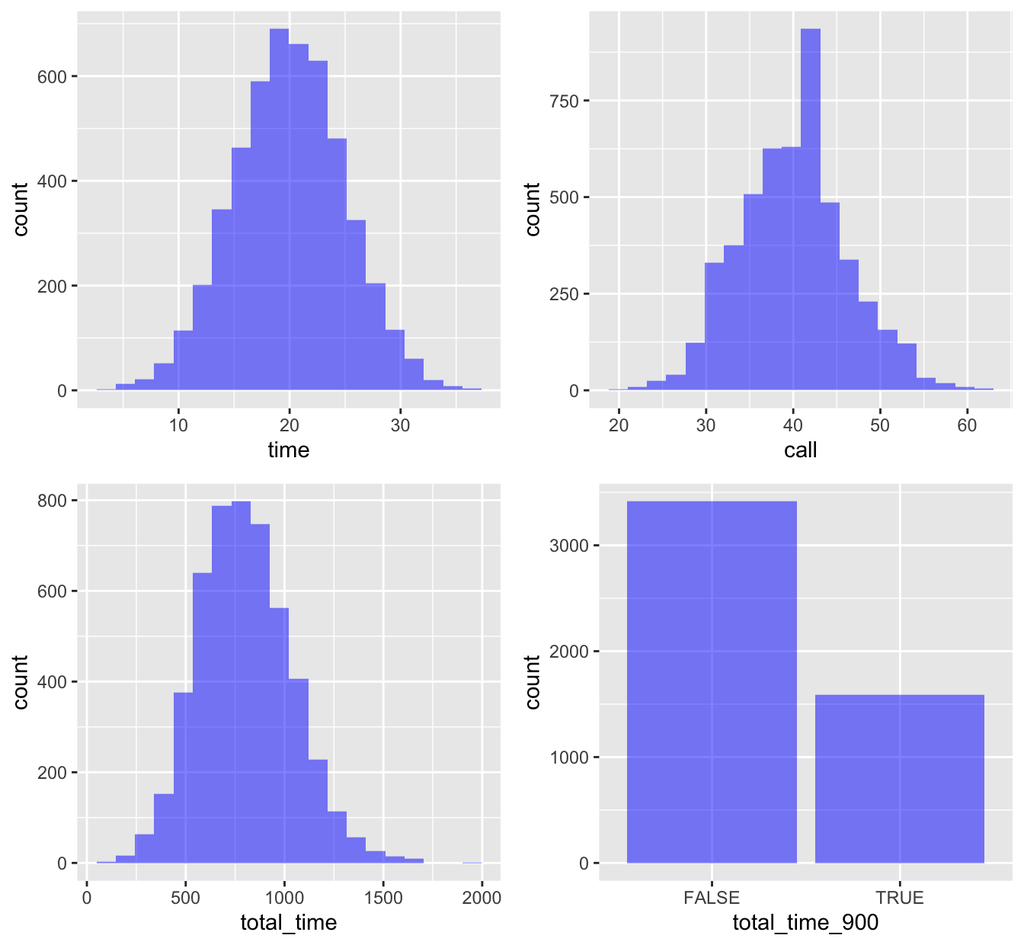

```r
plot(simdat, custom = FALSE)
```

```r
register("simdat")
```